# DATA 589 Project - Single covariate modelling - Distance to Water

### Seasonal Distance to Water Effects

```r
options(scipen = 999) # remove scientific notation

# model for each season (individually)
models_seasonal <- list()

for (season in names(ppp_list)) {
  models_seasonal[[season]] <- ppm(ppp_list[[season]], ~ dist_water, covariates = list(dist_water))
  cat("Model for", season, ":\n")
  print(models_seasonal[[season]])
}
```

```
## Model for winter :
## Nonstationary Poisson process
## Fitted to point pattern dataset 'ppp_list[[season]]'
##
## Log intensity:  ~dist_water
##
## Fitted trend coefficients:
##     (Intercept)      dist_water
## -23.29101304219   0.00001082552
##
##                    Estimate          S.E.        CI95.lo        CI95.hi Ztest
## (Intercept) -23.29101304219 0.15745261269 -23.5996144923 -22.9824115920   ***
## dist_water    0.00001082552 0.00006229574  -0.0001112719   0.0001329229
##                     Zval
## (Intercept) -147.9239540
## dist_water     0.1737762
## Model for spring :
## Nonstationary Poisson process
## Fitted to point pattern dataset 'ppp_list[[season]]'
##
## Log intensity:  ~dist_water
##
## Fitted trend coefficients:
##     (Intercept)      dist_water
## -20.86235342227  -0.00004261299
##
##                    Estimate          S.E.         CI95.lo            CI95.hi
## (Intercept) -20.86235342227 0.04918876184 -20.95876162391 -20.76594522063145
## dist_water   -0.00004261299 0.00002171202  -0.00008516777  -0.00000005821493
##             Ztest        Zval
## (Intercept)   *** -424.128452
## dist_water      *   -1.962645
## Model for summer :
## Nonstationary Poisson process
## Fitted to point pattern dataset 'ppp_list[[season]]'
##
## Log intensity:  ~dist_water
##
## Fitted trend coefficients:
##     (Intercept)      dist_water
```

[output cut: 9 more lines]

```
## Nonstationary Poisson process
## Fitted to point pattern dataset 'ppp_list[[season]]'
##
## Log intensity:  ~dist_water
##
## Fitted trend coefficients:
##    (Intercept)     dist_water
## -20.7231862559  -0.0001129178
##
##                   Estimate          S.E.       CI95.lo         CI95.hi Ztest
## (Intercept) -20.7231862559 0.04861435702 -20.818468645 -20.62790386706   ***
## dist_water   -0.0001129178 0.00002467912  -0.000161288  -0.00006454759   ***
##                    Zval
## (Intercept) -426.277082
## dist_water    -4.575437
```

**Interpretation:**

1. **Winter**
- Intercept: significant
- Slope (dist_water): (p > 0.05) not significant
- **Interpretation:**
  - Bear occurrence does not significantly vary with distance to water. The flat slope suggests distance to water is not an important factor in winter — possibly because bears are less mobile due to hibernation.
2. **Spring**
- Intercept: significant
- Slope (dist_water): -4.26e-05, p ≈ 0.05 (*)
- **Interpretation:**
  - There’s weak evidence that bear occurrence decreases with increasing distance from water. Bears may start to rely on water sources as they emerge from hibernation and become active.
3. **Summer**
- Intercept: significant
- Slope (dist_water): p < 0.05 (*)
- **Interpretation:**
  - Bear occurrence significantly decreases with distance from water.This is ecologically expected, as summer means more activity, foraging, and need for hydration.
4. **Autumn**
- Intercept: -20.72 (significant)
- Slope (dist_water): -1.13e-04, p < 0.001 (***)
- **Interpretation:**
  - Bears are strongly associated with areas closer to water.This is the strongest seasonal effect — likely due to pre-hibernation foraging and increased movement and calorie intake near water sources.

#### Model Evaluation

```r
# Calculate partial residuals for each season's model
partial_residuals_seasonal <- list()

for (season in names(models_seasonal)) {
  partial_residuals_seasonal[[season]] <- parres(models_seasonal[[season]], covariate = "dist_water")
}
```

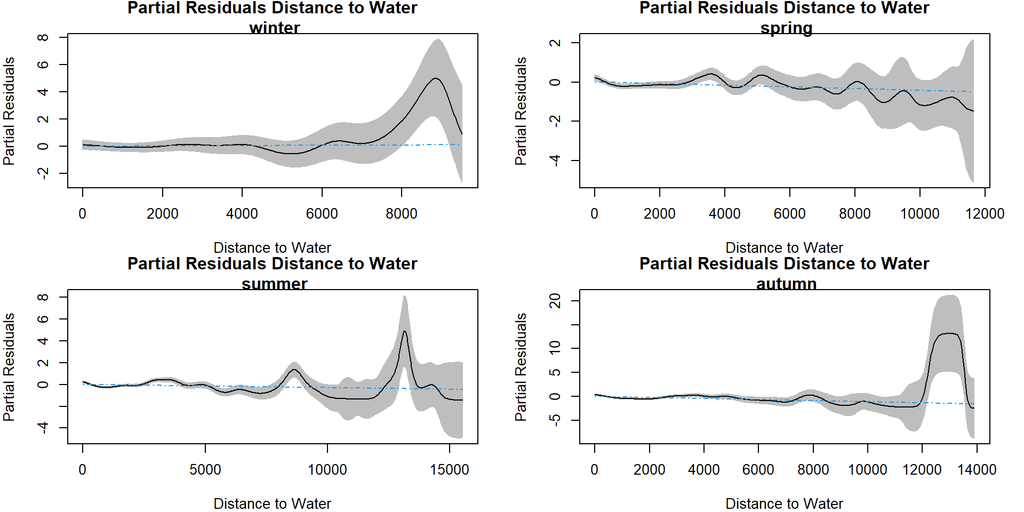

```r
# Plot partial residuals in a 2x2 grid
par(mfrow = c(2, 2), mar = c(4, 4, 2, 2))  # Larger margins for axes and labels

for (i in seq_along(partial_residuals_seasonal)) {
  season_name <- names(partial_residuals_seasonal)[i]
  plot(
    partial_residuals_seasonal[[i]],
    main = paste("Partial Residuals Distance to Water\n", season_name),
    xlab = "Distance to Water",
    ylab = 'Partial Residuals',
    legend = F
  )
}
```